# Google Capstone Case Study 1

Prateek Srivastava

2023-02-03

# Ask

**About Cyclistic**

A bike-share program that features more than 5,800 bicycles and 600 docking stations. Cyclistic sets itself apart by also offering reclining bikes, hand tricycles, and cargo bikes, making bike-share more inclusive to people with disabilities and riders who can’t use a standard two-wheeled bike. The majority of riders opt for traditional bikes; about 8% of riders use the assistive options. Cyclistic users are more likely to ride for leisure, but about 30% use them to commute to work each day.

**Stakeholders**

- **Lily Moreno:** The director of marketing
- **Cyclistic marketing analytics team**
- **Cyclistic executive team**

**Key Questions**

Three questions that will guide the future marketing program:

1. How do annual members and casual riders use Cyclistic bikes differently?
2. Why would casual riders buy Cyclistic annual memberships?
3. How can Cyclistic use digital media to influence casual riders to become members?

**In this case study we will be focusing on the first question**

# Prepare

**Verifying Data Integrity**

- The data has been provided by the internal company servers and is vetted by the company
- We are using only the last year that is Jan 22- Dec 22 data for analysis

# Process

- Load all the necessary packages in Rstudio

```r
library(dplyr)
library(readr)
library(tidyverse)
```

```r
library(ggplot2)
library(lubridate)
```

- Set the default working directory to the folder where the input files are stored

```r
setwd("~/Divvy_2022")
```

- Upon inspecting the csv it was found that the column names are same and values present in the respective columns are belonging to the respective data points hence, these csv files can be aggregated into one single data frame for further analysis.
- There are some datetime values that are of character type and some of datetime type. We have to convert all the date values into the datetime format
- Read all the csv files and combine them all in one single dataframe
- add the columns for ride_time and day_of_ride in the dataframe

```r
df <-
  list.files(path = 'C://Users//ayush//Documents//Divvy_2022//', pattern = "*.csv") %>%
  map_df(~read_csv(.))
df
```

```
## # A tibble: 5,667,717 × 13
##    ride_id       ridea…¹ started_at          ended_at            start…² start…³
##    <chr>         <chr>   <dttm>              <dttm>              <chr>   <chr>
##  1 C2F7DD78E82E… electr… 2022-01-13 11:59:47 2022-01-13 12:02:44 Glenwo… 525
##  2 A6CF8980A652… electr… 2022-01-10 08:41:56 2022-01-10 08:46:17 Glenwo… 525
##  3 BD0F91DFF741… classi… 2022-01-25 04:53:40 2022-01-25 04:58:01 Sheffi… TA1306…
##  4 CBB80ED41910… classi… 2022-01-04 00:18:04 2022-01-04 00:33:00 Clark … KA1504…
##  5 DDC963BFDDA5… classi… 2022-01-20 01:31:10 2022-01-20 01:37:12 Michig… TA1309…
##  6 A39C6F6CC058… classi… 2022-01-11 18:48:09 2022-01-11 18:51:31 Wood S… 637
##  7 BDC4AB637EDF… classi… 2022-01-30 18:32:52 2022-01-30 18:49:26 Oakley… KA1504…
##  8 81751A3186E5… classi… 2022-01-22 12:20:02 2022-01-22 12:32:06 Sheffi… TA1306…
##  9 154222B86A33… electr… 2022-01-17 07:34:41 2022-01-17 08:00:08 Racine… 13304
## 10 72DC25B2DD46… classi… 2022-01-28 15:27:53 2022-01-28 15:35:16 LaSall… TA1309…
## # … with 5,667,707 more rows, 7 more variables: end_station_name <chr>,
## #   end_station_id <chr>, start_lat <dbl>, start_lng <dbl>, end_lat <dbl>,
## #   end_lng <dbl>, member_casual <chr>, and abbreviated variable names
## #   ¹rideable_type, ²start_station_name, ³start_station_id
```

- Inserting the ride_time and day_of_week columns in the dataframe

```r
df$ride_time<-df$ended_at-df$started_at
df$day_of_ride<-wday(df$started_at, label=TRUE, abbr=FALSE)
df$month_of_ride<-format(as.Date(df$started_at, format="%Y-%m-%d"),"%m")
```

- Viewing the attributes of the combined dataset using the head and str functions

```r
head(df)
```

```
## # A tibble: 6 × 16
##   ride_id        ridea…¹ started_at          ended_at            start…² start…³
##   <chr>          <chr>   <dttm>              <dttm>              <chr>   <chr>
## 1 C2F7DD78E82EC… electr… 2022-01-13 11:59:47 2022-01-13 12:02:44 Glenwo… 525
## 2 A6CF8980A652D… electr… 2022-01-10 08:41:56 2022-01-10 08:46:17 Glenwo… 525
## 3 BD0F91DFF741C… classi… 2022-01-25 04:53:40 2022-01-25 04:58:01 Sheffi… TA1306…
## 4 CBB80ED419105… classi… 2022-01-04 00:18:04 2022-01-04 00:33:00 Clark … KA1504…
## 5 DDC963BFDDA51… classi… 2022-01-20 01:31:10 2022-01-20 01:37:12 Michig… TA1309…
## 6 A39C6F6CC0586… classi… 2022-01-11 18:48:09 2022-01-11 18:51:31 Wood S… 637
## # … with 10 more variables: end_station_name <chr>, end_station_id <chr>,
## #   start_lat <dbl>, start_lng <dbl>, end_lat <dbl>, end_lng <dbl>,
## #   member_casual <chr>, ride_time <drtn>, day_of_ride <ord>,
## #   month_of_ride <chr>, and abbreviated variable names ¹rideable_type,
## #   ²start_station_name, ³start_station_id
```

```r
str(df)
```

```
## spc_tbl_ [5,667,717 × 16] (S3: spec_tbl_df/tbl_df/tbl/data.frame)
##  $ ride_id           : chr [1:5667717] "C2F7DD78E82EC875" "A6CF8980A652D272" "BD0F91DFF741C66D" "CBB80ED419105406" ...
##  $ rideable_type     : chr [1:5667717] "electric_bike" "electric_bike" "classic_bike" "classic_bike" ...
##  $ started_at        : POSIXct[1:5667717], format: "2022-01-13 11:59:47" "2022-01-10 08:41:56" ...
##  $ ended_at          : POSIXct[1:5667717], format: "2022-01-13 12:02:44" "2022-01-10 08:46:17" ...
##  $ start_station_name: chr [1:5667717] "Glenwood Ave & Touhy Ave" "Glenwood Ave & Touhy Ave" "Sheffield Ave & Fullerton Ave" "Clark St & Bryn Mawr Ave" ...
##  $ start_station_id  : chr [1:5667717] "525" "525" "TA1306000016" "KA1504000151" ...
##  $ end_station_name  : chr [1:5667717] "Clark St & Touhy Ave" "Clark St & Touhy Ave" "Greenview Ave & Fullerton Ave" "Paulina St & Montrose Ave" ...
##  $ end_station_id    : chr [1:5667717] "RP-007" "RP-007" "TA1307000001" "TA1309000021" ...
##  $ start_lat         : num [1:5667717] 42 42 41.9 42 41.9 ...
##  $ start_lng         : num [1:5667717] -87.7 -87.7 -87.7 -87.7 -87.6 ...
##  $ end_lat           : num [1:5667717] 42 42 41.9 42 41.9 ...
##  $ end_lng           : num [1:5667717] -87.7 -87.7 -87.7 -87.7 -87.6 ...
##  $ member_casual     : chr [1:5667717] "casual" "casual" "member" "casual" ...
##  $ ride_time         : 'difftime' num [1:5667717] 177 261 261 896 ...
##   ..- attr(*, "units")= chr "secs"
##  $ day_of_ride       : Ord.factor w/ 7 levels "Sunday"<"Monday"<..: 5 2 3 3 5 3 1 7 2 6 ...
##  $ month_of_ride     : chr [1:5667717] "01" "01" "01" "01" ...
##  - attr(*, "spec")=
##   .. cols(
##   ..   ride_id = col_character(),
##   ..   rideable_type = col_character(),
##   ..   started_at = col_datetime(format = ""),
##   ..   ended_at = col_datetime(format = ""),
##   ..   start_station_name = col_character(),
##   ..   start_station_id = col_character(),
##   ..   end_station_name = col_character(),
##   ..   end_station_id = col_character(),
##   ..   start_lat = col_double(),
##   ..   start_lng = col_double(),
##   ..   end_lat = col_double(),
##   ..   end_lng = col_double(),
##   ..   member_casual = col_character()
##   .. )
##  - attr(*, "problems")=<externalptr>
```

- Upon Inspecting the dataframe we observe that there are certain negative values for the ride_time column that we have created earlier

```r
df1<-df %>% filter(ride_time<0)
head(df1)
```

```
## # A tibble: 6 × 16
##   ride_id        ridea…¹ started_at          ended_at            start…² start…³
##   <chr>          <chr>   <dttm>              <dttm>              <chr>   <chr>
## 1 2D97E3C98E165… classi… 2022-03-05 11:00:57 2022-03-05 10:55:01 DuSabl… TA1307…
## 2 7407049C5D89A… electr… 2022-03-05 11:38:04 2022-03-05 11:37:57 Sheffi… TA1307…
## 3 0793C9208A643… electr… 2022-05-30 11:06:29 2022-05-30 11:06:17 Broadw… 13325
## 4 B897BE02B21FA… electr… 2022-06-07 19:15:39 2022-06-07 17:05:37 <NA>    <NA>
## 5 072E947E156D1… electr… 2022-06-07 19:14:46 2022-06-07 17:07:45 W Armi… 20254.0
## 6 6A871510E302E… electr… 2022-06-23 19:22:57 2022-06-23 19:21:46 <NA>    <NA>
## # … with 10 more variables: end_station_name <chr>, end_station_id <chr>,
## #   start_lat <dbl>, start_lng <dbl>, end_lat <dbl>, end_lng <dbl>,
## #   member_casual <chr>, ride_time <drtn>, day_of_ride <ord>,
## #   month_of_ride <chr>, and abbreviated variable names ¹rideable_type,
## #   ²start_station_name, ³start_station_id
```

- As the ride time cannot be zero or negative hence we will filter the data and store it in the original dataframe

```r
df<-df %>% filter(ride_time>0)
head(df)
```

```
## # A tibble: 6 × 16
##   ride_id        ridea…¹ started_at          ended_at            start…² start…³
##   <chr>          <chr>   <dttm>              <dttm>              <chr>   <chr>
## 1 C2F7DD78E82EC… electr… 2022-01-13 11:59:47 2022-01-13 12:02:44 Glenwo… 525
## 2 A6CF8980A652D… electr… 2022-01-10 08:41:56 2022-01-10 08:46:17 Glenwo… 525
## 3 BD0F91DFF741C… classi… 2022-01-25 04:53:40 2022-01-25 04:58:01 Sheffi… TA1306…
## 4 CBB80ED419105… classi… 2022-01-04 00:18:04 2022-01-04 00:33:00 Clark … KA1504…
## 5 DDC963BFDDA51… classi… 2022-01-20 01:31:10 2022-01-20 01:37:12 Michig… TA1309…
## 6 A39C6F6CC0586… classi… 2022-01-11 18:48:09 2022-01-11 18:51:31 Wood S… 637
## # … with 10 more variables: end_station_name <chr>, end_station_id <chr>,
## #   start_lat <dbl>, start_lng <dbl>, end_lat <dbl>, end_lng <dbl>,
## #   member_casual <chr>, ride_time <drtn>, day_of_ride <ord>,
## #   month_of_ride <chr>, and abbreviated variable names ¹rideable_type,
## #   ²start_station_name, ³start_station_id
```

- Now we have clean aggregated data in a single dataframe. Proceeding to the next step i.e. Analyze

# Analyze

- We will be creating new dataframes containing different analysis from the original one
- Mean ride time on the Weekdays

```r
df1<-df %>%
  group_by(day_of_ride) %>%
  summarize(ride_time=mean(ride_time))
df1
```

```
## # A tibble: 7 × 2
##   day_of_ride ride_time
##   <ord>       <drtn>
## 1 Sunday      1444.1791 secs
## 2 Monday      1111.5745 secs
## 3 Tuesday     1004.8086 secs
## 4 Wednesday    987.1403 secs
## 5 Thursday    1029.9694 secs
## 6 Friday      1140.4957 secs
## 7 Saturday    1420.8415 secs
```

- User type, weekday and Mean ride time

```r
df2<-df %>%
  group_by(member_casual,day_of_ride) %>%
  summarize(number_of_rides=n(),ride_time=mean(ride_time))
df2
```

```
## # A tibble: 14 × 4
## # Groups:   member_casual [2]
##    member_casual day_of_ride number_of_rides ride_time
##    <chr>         <ord>                 <int> <drtn>
##  1 casual        Sunday               388981 2043.6343 secs
##  2 casual        Monday               277649 1751.3805 secs
##  3 casual        Tuesday              263706 1549.5189 secs
##  4 casual        Wednesday            274339 1485.1319 secs
##  5 casual        Thursday             309297 1533.0238 secs
##  6 casual        Friday               334667 1682.8110 secs
##  7 casual        Saturday             473130 1957.0725 secs
##  8 member        Sunday               387180  841.9355 secs
##  9 member        Monday               473305  736.2531 secs
## 10 member        Tuesday              518584  727.8171 secs
## 11 member        Wednesday            523836  726.3364 secs
## 12 member        Thursday             532215  737.6191 secs
## 13 member        Friday               467051  751.8978 secs
## 14 member        Saturday             443246  848.4573 secs
```

- Mean ride time of the user type

```r
df3<-df %>%
  group_by(member_casual) %>%
  summarize(ride_time=mean(ride_time))
df3
```

```
## # A tibble: 2 × 2
##   member_casual ride_time
##   <chr>         <drtn>
## 1 casual        1748.9000 secs
## 2 member         762.8915 secs
```

- Number of rides per month along with user type

```r
df4<-df %>%
  group_by(member_casual,month_of_ride) %>%
  summarize(number_of_rides=n())
df4
```

```
## # A tibble: 24 × 3
## # Groups:   member_casual [2]
##    member_casual month_of_ride number_of_rides
##    <chr>         <chr>                   <int>
##  1 casual        01                      18517
##  2 casual        02                      21414
##  3 casual        03                      89874
##  4 casual        04                     126398
##  5 casual        05                     280387
##  6 casual        06                     369022
##  7 casual        07                     406013
##  8 casual        08                     358886
##  9 casual        09                     296664
## 10 casual        10                     208961
## # … with 14 more rows
```

- Number of rides per week along with user type

```r
df5<-df %>%
  group_by(member_casual,day_of_ride) %>%
  summarize(number_of_rides=n())
df5
```

```
## # A tibble: 14 × 3
## # Groups:   member_casual [2]
##    member_casual day_of_ride number_of_rides
##    <chr>         <ord>                 <int>
##  1 casual        Sunday               388981
##  2 casual        Monday               277649
##  3 casual        Tuesday              263706
##  4 casual        Wednesday            274339
##  5 casual        Thursday             309297
##  6 casual        Friday               334667
##  7 casual        Saturday             473130
##  8 member        Sunday               387180
##  9 member        Monday               473305
## 10 member        Tuesday              518584
## 11 member        Wednesday            523836
## 12 member        Thursday             532215
## 13 member        Friday               467051
## 14 member        Saturday             443246
```

# Share

The below visualizations are made by using the analysis we have done in the last step

- **Average ride time on weekdays**

```
## Defaulting to continuous.
```

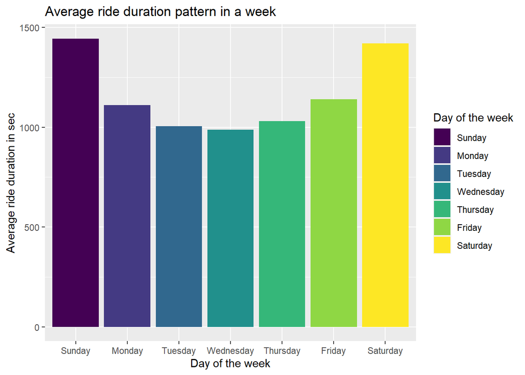

```r
ggplot(data=df1,aes(x=day_of_ride,y=ride_time,fill=day_of_ride))+geom_col()+
  labs(title = "Average ride duration pattern in a week", x = 'Day of the week', y = 'Average ride duration in sec', fill = 'Day of the week')
```

- **Average ride time on weekdays as per User type**

```
## Defaulting to continuous.
```

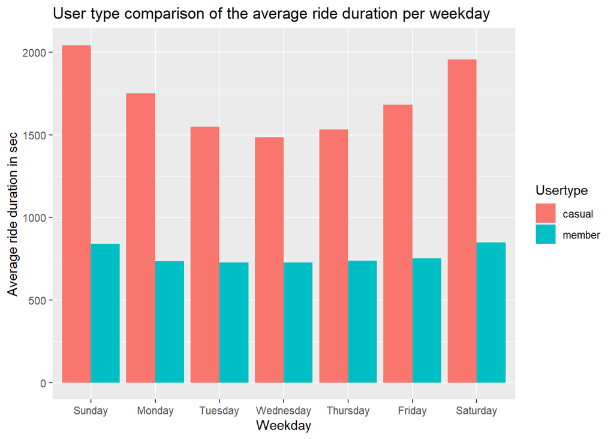

```r
ggplot(data=df2)+geom_col(mapping=aes(x=day_of_ride,member_casual, y=ride_time,fill=member_casual), position = 'dodge')+
  labs(title = "User type comparison of the average ride duration per weekday", x = 'Weekday', y = 'Average ride duration in sec', fill = 'Usertype')
```

- **Average ride time as per User type**

```
## Defaulting to continuous.
```

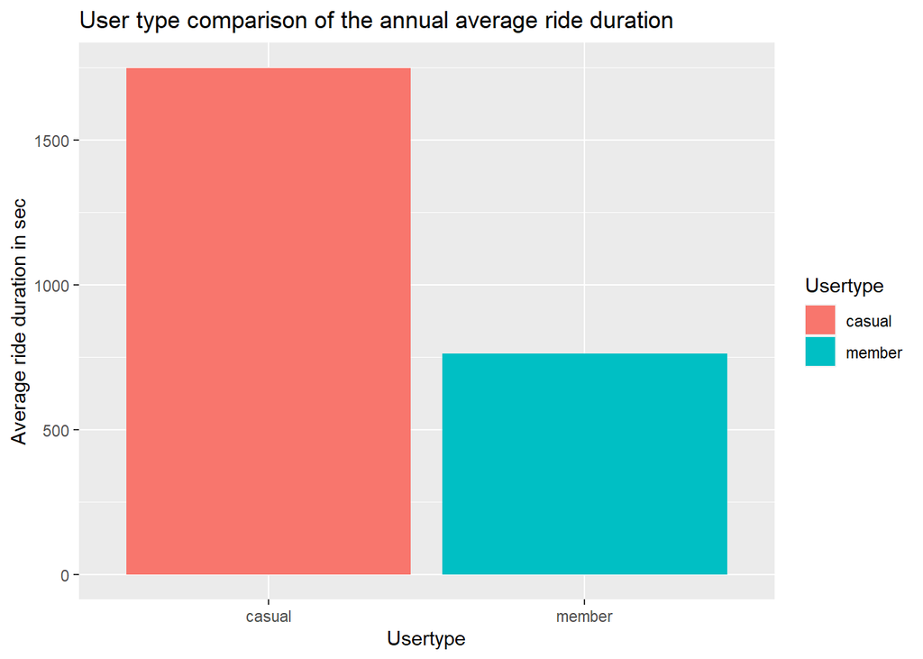

```r
ggplot(data=df3)+geom_col(mapping=aes(x=member_casual, y=ride_time, fill=member_casual), position = 'dodge')+
  labs(title = "User type comparison of the annual average ride duration", x = 'Usertype', y = 'Average ride duration in sec', fill = 'Usertype')
```

- **Monthly comparison of the number of rides for different User types**

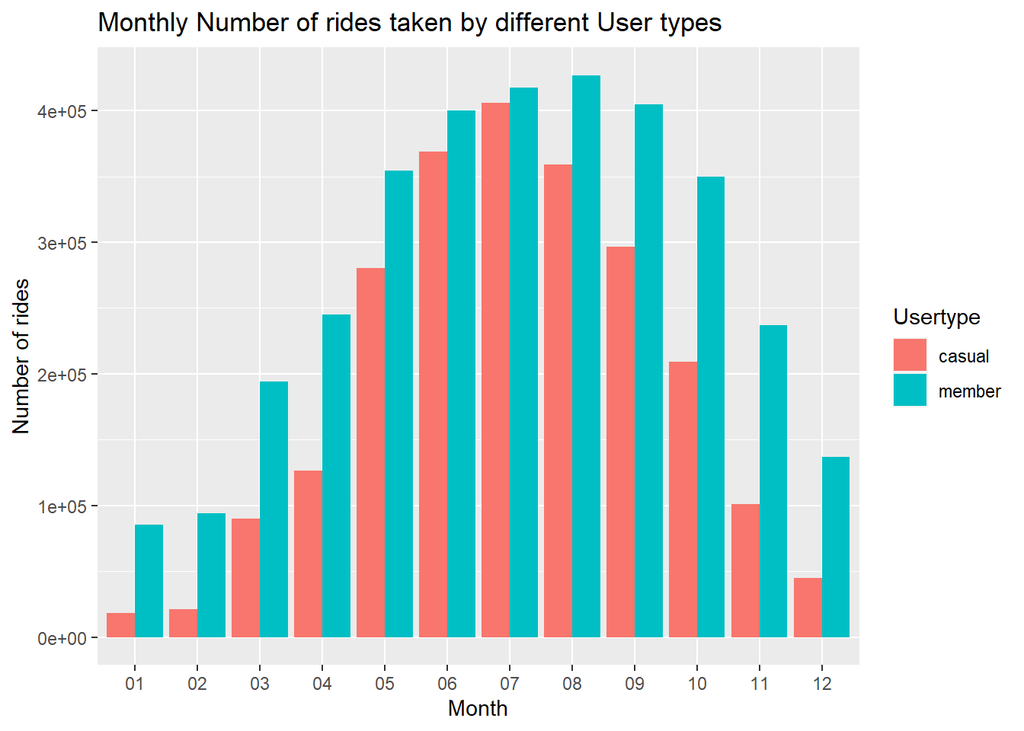

```r
ggplot(data=df4)+geom_col(mapping=aes(x=month_of_ride, y=number_of_rides, fill=member_casual), position = 'dodge')+
  labs(title = "Monthly Number of rides taken by different User types", x = 'Month', y = 'Number of rides', fill = 'Usertype')
```

- **Weekday comparison of the number of rides for different User types**

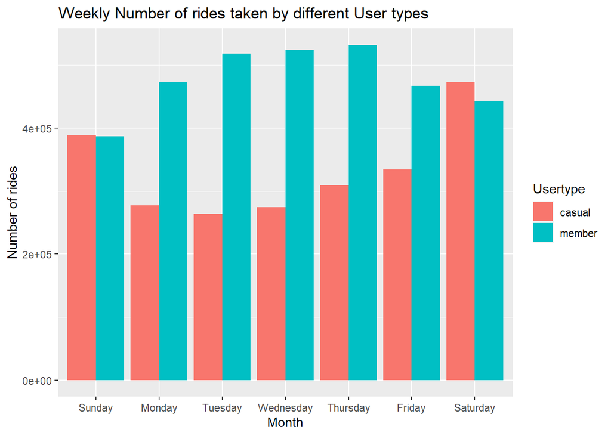

```r
ggplot(data=df5)+geom_col(mapping=aes(x=day_of_ride, y=number_of_rides, fill=member_casual), position = 'dodge')+
  labs(title = "Weekly Number of rides taken by different User types", x = 'Month', y = 'Number of rides', fill = 'Usertype')
```

# Act